# WHO Covid Data Analysis

This project seeks to examine the impact of the Covid-19 pandemic on various countries, age, sex and income group in terms of excess deaths using data obtained from the World Health Organization (WHO). Data Analytics tools and techniques are heavily deployed using the Pandas library in python.

```python
import warnings
warnings.simplefilter('ignore', FutureWarning) # to hide some warnings

from pandas import *
from datetime import datetime
```

## Data Source

The data used for this analysis was obtained from the World Health Organisation through the following link

https://www.who.int/data/sets/global-excess-deaths-associated-with-covid-19-modelled-estimates

I downloaded the excel file so it can be readily accessed offline.

## Reading the Appropriate Spreadsheet in Excel File

We read the excel file from its path. We do not need to read all spreadsheets as we are only working with the 3rd spreadsheet. The first 10 rows are notes concerning what the column names mean. We do not need to read them into our dataframe. The heading row is the 11th. Putting all these into consideration, we read the excel file into pandas dataframe thus:

```python
covid_df = read_excel('C:\\Users\\Engr.Kayode\\Documents\\OpenLearning\\Data_analysis/WHO_COVID_Excess_Deaths_EstimatesByRegion.xlsx', sheet_name=2, header=10)
```

```python
covid_df.head(10)
```

|  | location | year | sex | age | Nx | type | expected.mean | acm.mean | excess.mean |
| --- | --- | --- | --- | --- | --- | --- | --- | --- | --- |
| 0 | Global | 2020 | Female | 0 to 24 | 1538964911 | Predicted | 3097545 | 3076216 | -21329 |
| 1 | Global | 2020 | Female | 25 to 39 | 849485348 | Predicted | 1013026 | 957939 | -55087 |
| 2 | Global | 2020 | Female | 40 to 49 | 479860230 | Predicted | 1190126 | 1214924 | 24798 |
| 3 | Global | 2020 | Female | 50 to 59 | 416231682 | Predicted | 2204775 | 2387178 | 182403 |
| 4 | Global | 2020 | Female | 60 to 69 | 303533101 | Predicted | 3723836 | 4226869 | 503033 |
| 5 | Global | 2020 | Female | 70 to 79 | 169385113 | Predicted | 5059377 | 5570299 | 510922 |
| 6 | Global | 2020 | Female | 80 plus | 88885126 | Predicted | 9209962 | 9972889 | 762927 |
| 7 | Global | 2020 | Male | 0 to 24 | 1642942104 | Predicted | 3935540 | 3903455 | -32085 |
| 8 | Global | 2020 | Male | 25 to 39 | 887853298 | Predicted | 1803677 | 1659002 | -144675 |
| 9 | Global | 2020 | Male | 40 to 49 | 488028531 | Predicted | 2078096 | 2114879 | 36783 |

```python
covid_df.tail(5)
```

|  | location | year | sex | age | Nx | type | expected.mean | acm.mean | excess.mean |
| --- | --- | --- | --- | --- | --- | --- | --- | --- | --- |
| 191 | WPR | 2021 | Male | 40 to 49 | 140741238 | Predicted | 439057 | 421866 | -17191 |
| 192 | WPR | 2021 | Male | 50 to 59 | 144547081 | Predicted | 925160 | 955158 | 29998 |
| 193 | WPR | 2021 | Male | 60 to 69 | 98388414 | Predicted | 1618203 | 1741820 | 123617 |
| 194 | WPR | 2021 | Male | 70 to 79 | 49958251 | Predicted | 2023275 | 2136310 | 113035 |
| 195 | WPR | 2021 | Male | 80 plus | 18062304 | Predicted | 2709552 | 2671721 | -37831 |

*Table showing Covid deaths in Each Region by year, sex and age*

#### *Notes on the Column*

The notes on the WHO excel sheet has the following explanation on the column names

- location => Region (Global or WHO region), AFR: African Region; AMR: Region of the Americas; EMR: Eastern Mediterranean Region; EUR: European Region; WPR: Western Pacific Region; SEAR: South-East Asia Region
- year => Year of death
- sex => Sex (Female or Male)
- age => Age-group from 0 to 80 plus
- Nx => Sex- and age-specific population number
- type => Estimate type for select year (reported or predicted)
- expected.mean => Expected deaths from all-causes by age, sex and year (mean)
- acm.mean => Estimated deaths from all-causes by by age, sex and year (mean)
- excess.mean => Excess deaths associated with COVID-19 pandemic from all-causes by age, sex and year (mean)

#### Column Reselection

We re-choose only columns relevant to our study and drop others. Then rename to our choice.

We drop the following columns

1. type
2. expected.mean, and
3. acm.mean.

```python
covid_df = covid_df[['location', 'year', 'sex', 'age', 'Nx', 'excess.mean']] # retained columns
```

```python
# Hold column names with variables
LOC='Region'
YEAR='Year'
SEX='Sex'
AGE='Age'
POP='Population'
DEATHS='Deaths'

# Rename column names
covid_df.columns = [LOC, YEAR, SEX, AGE, POP, DEATHS]
covid_df.head(20).tail() # show row 15-19
```

|  | Region | Year | Sex | Age | Population | Deaths |
| --- | --- | --- | --- | --- | --- | --- |
| 15 | Global | 2021 | Female | 25 to 39 | 854657794 | 112998 |
| 16 | Global | 2021 | Female | 40 to 49 | 483126003 | 223853 |
| 17 | Global | 2021 | Female | 50 to 59 | 423939051 | 572093 |
| 18 | Global | 2021 | Female | 60 to 69 | 310302230 | 1131447 |
| 19 | Global | 2021 | Female | 70 to 79 | 176323877 | 1173664 |

### Data Cleaning

The first stage of cleaning has already been done, that is, the removal of unneeded columns in the reading of the excel file. Next, we check that we have the correct data type in every column. We also check for invalid data

#### Data Type Check

```python
covid_df.dtypes
```

```
Region        object
Year           int64
Sex           object
Age           object
Population     int64
Deaths         int64
dtype: object
```

#### Invalid Data Check

Find any NAN row

```python
["The number of invalid rows in each column = ",(
    len(covid_df[covid_df[LOC].isnull()]),
    len(covid_df[covid_df[YEAR].isnull()]),
    len(covid_df[covid_df[SEX].isnull()]),
    len(covid_df[covid_df[AGE].isnull()]),
    len(covid_df[covid_df[POP].isnull()]),
    len(covid_df[covid_df[DEATHS].isnull()])
)]
```

```
['The number of invalid rows in each column = ', (0, 0, 0, 0, 0, 0)]
```

The datasets are clean. Let's visualize in graphical form

```python
covid_df
```

|  | Region | Year | Sex | Age | Population | Deaths |
| --- | --- | --- | --- | --- | --- | --- |
| 0 | Global | 2020 | Female | 0 to 24 | 1538964911 | -21329 |
| 1 | Global | 2020 | Female | 25 to 39 | 849485348 | -55087 |
| 2 | Global | 2020 | Female | 40 to 49 | 479860230 | 24798 |
| 3 | Global | 2020 | Female | 50 to 59 | 416231682 | 182403 |
| 4 | Global | 2020 | Female | 60 to 69 | 303533101 | 503033 |
| ... | ... | ... | ... | ... | ... | ... |
| 191 | WPR | 2021 | Male | 40 to 49 | 140741238 | -17191 |
| 192 | WPR | 2021 | Male | 50 to 59 | 144547081 | 29998 |
| 193 | WPR | 2021 | Male | 60 to 69 | 98388414 | 123617 |
| 194 | WPR | 2021 | Male | 70 to 79 | 49958251 | 113035 |
| 195 | WPR | 2021 | Male | 80 plus | 18062304 | -37831 |

196 rows × 6 columns

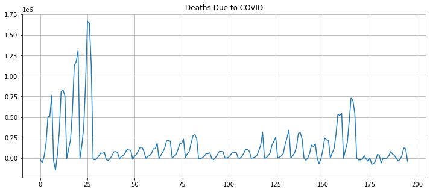

```python
%matplotlib inline
covid_df[DEATHS].plot(grid=True, figsize=(12,5), title='Deaths Due to COVID')
```

Death figures alone cannot form a fair basis for comparison if we do not consider the population of the group we are comparing. Therefore we create another column 'Death Rate' that is simply a division of deaths by number of persons in the group.

```python
RATE='Death Rate (Per Million)'
covid_df[RATE] = covid_df[DEATHS]/covid_df[POP] *1000000
covid_df.head(10)
```

|  | Region | Year | Sex | Age | Population | Deaths | Death Rate (Per Million) |
| --- | --- | --- | --- | --- | --- | --- | --- |
| 0 | Global | 2020 | Female | 0 to 24 | 1538964911 | -21329 | -13.859315 |
| 1 | Global | 2020 | Female | 25 to 39 | 849485348 | -55087 | -64.847499 |
| 2 | Global | 2020 | Female | 40 to 49 | 479860230 | 24798 | 51.677548 |
| 3 | Global | 2020 | Female | 50 to 59 | 416231682 | 182403 | 438.224690 |
| 4 | Global | 2020 | Female | 60 to 69 | 303533101 | 503033 | 1657.259120 |
| 5 | Global | 2020 | Female | 70 to 79 | 169385113 | 510922 | 3016.333555 |
| 6 | Global | 2020 | Female | 80 plus | 88885126 | 762927 | 8583.292102 |
| 7 | Global | 2020 | Male | 0 to 24 | 1642942104 | -32085 | -19.528990 |
| 8 | Global | 2020 | Male | 25 to 39 | 887853298 | -144675 | -162.949217 |
| 9 | Global | 2020 | Male | 40 to 49 | 488028531 | 36783 | 75.370593 |

Let's round to nearest million by using a function roundRate, and then use the apply method to overwrite the Death Rate column

```python
def roundRate(x):
    return round(x)

covid_df[RATE]=covid_df[RATE].apply(roundRate)
covid_df.head(7)
```

|  | Region | Year | Sex | Age | Population | Deaths | Death Rate (Per Million) |
| --- | --- | --- | --- | --- | --- | --- | --- |
| 0 | Global | 2020 | Female | 0 to 24 | 1538964911 | -21329 | -14 |
| 1 | Global | 2020 | Female | 25 to 39 | 849485348 | -55087 | -65 |
| 2 | Global | 2020 | Female | 40 to 49 | 479860230 | 24798 | 52 |
| 3 | Global | 2020 | Female | 50 to 59 | 416231682 | 182403 | 438 |
| 4 | Global | 2020 | Female | 60 to 69 | 303533101 | 503033 | 1657 |
| 5 | Global | 2020 | Female | 70 to 79 | 169385113 | 510922 | 3016 |
| 6 | Global | 2020 | Female | 80 plus | 88885126 | 762927 | 8583 |

### SUM across each region

Below shows the sum of people and covid-19 death rates across each region. The values are sorted by death rate. Western Pacific Region seems to have the least total death rates.

```python
region = covid_df.groupby(LOC)
table = region[POP, RATE].aggregate(sum)
table.sort_values(RATE)
```

| Region | Population | Death Rate (Per Million) |
| --- | --- | --- |
| WPR | 3888001390 | -642 |
| Global | 15596307983 | 103037 |
| EUR | 1867899036 | 105831 |
| AMR | 2044283270 | 126400 |
| EMR | 1465099745 | 180851 |
| AFR | 2269080073 | 221046 |
| SEAR | 4061944469 | 229458 |

[figure not shown]

```python
table.plot.bar(y=RATE, figsize=(10,5), title='Covid-19 Total Death Rate across Regions' grid=True)
```

From the table and plot, SEAR has the highest death rate, while WPR has the lowest

### Mean and median

Let's look at the mean and median across the regions. Let's use the statistics module in python at this point

```python
import statistics as st
```

```python
table = region[POP, RATE].aggregate(st.mean)
table.sort_values(RATE)
```

| Region | Population | Death Rate (Per Million) |
| --- | --- | --- |
| WPR | 1.388572e+08 | -22.928571 |
| Global | 5.570110e+08 | 3679.892857 |
| EUR | 6.671068e+07 | 3779.678571 |
| AMR | 7.301012e+07 | 4514.285714 |
| EMR | 5.232499e+07 | 6458.964286 |
| AFR | 8.103857e+07 | 7894.500000 |
| SEAR | 1.450694e+08 | 8194.928571 |

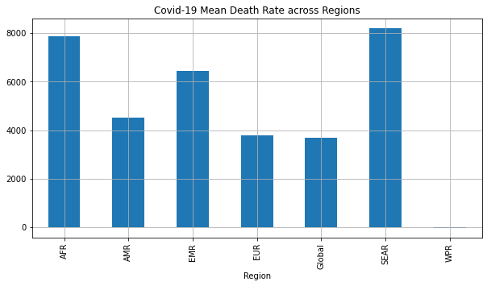

```python
table.plot.bar(y=RATE, figsize=(10,5), grid=True, legend=False, title='Covid-19 Mean Death Rate across Regions')
```

```python
table = region[POP, RATE].aggregate(st.median)
table.sort_values(RATE)
```

| Region | Population | Death Rate (Per Million) |
| --- | --- | --- |
| WPR | 138834696.0 | -4.0 |
| EUR | 61340595.5 | 1028.5 |
| Global | 418115603.5 | 1057.5 |
| EMR | 27415160.5 | 1422.5 |
| AFR | 30144201.5 | 1495.0 |
| AMR | 57622395.5 | 1923.5 |
| SEAR | 99679817.0 | 1934.0 |

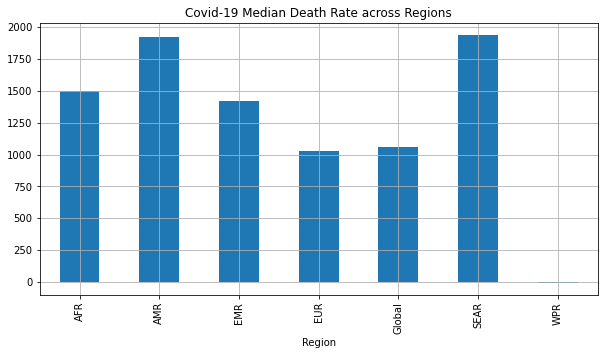

```python
table.plot.bar(y=RATE, figsize=(10,5), grid=True, legend=False, title='Covid-19 Median Death Rate across Regions')
```

### Grouping by Gender

Let's group by Gender

```python
sex = covid_df.groupby(SEX)
table = sex[RATE].aggregate(st.mean)
table
```

```
Sex
Female    3931.316327
Male      5925.632653
Name: Death Rate (Per Million), dtype: float64
```

### Region and Gender

```python
region_sex = covid_df.groupby([LOC,SEX])
table = region_sex[POP, RATE].aggregate(st.mean)
table
```

| Region | Sex | Population | Death Rate (Per Million) |
| --- | --- | --- | --- |
| AFR | Female | 8.114499e+07 | 6473.785714 |
|  | Male | 8.093215e+07 | 9315.214286 |
| AMR | Female | 7.402934e+07 | 3215.642857 |
|  | Male | 7.199090e+07 | 5812.928571 |
| EMR | Female | 5.061975e+07 | 5297.357143 |
|  | Male | 5.403023e+07 | 7620.571429 |
| EUR | Female | 6.868130e+07 | 2913.714286 |
|  | Male | 6.474006e+07 | 4645.642857 |
| Global | Female | 5.523211e+08 | 2872.357143 |
|  | Male | 5.617009e+08 | 4487.428571 |
| SEAR | Female | 1.414570e+08 | 6655.000000 |
|  | Male | 1.486819e+08 | 9734.857143 |
| WPR | Female | 1.363888e+08 | 91.357143 |
|  | Male | 1.413256e+08 | -137.214286 |

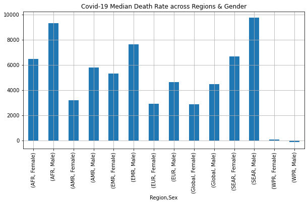

```python
table.plot.bar(y=RATE, figsize=(10,5), grid=True, legend=False, title='Covid-19 Median Death Rate across Regions & Gender')
```

### Pivot Table

```python
pivot_table(covid_df, index=[LOC, SEX], columns=AGE, values=RATE, aggfunc=st.median, margins=True)
```

| Region | Age Sex | 0 to 24 | 25 to 39 | 40 to 49 | 50 to 59 | 60 to 69 | 70 to 79 | 80 plus | All |
| --- | --- | --- | --- | --- | --- | --- | --- | --- | --- |
| AFR | Female | -33.0 | -15.5 | 280.5 | 1411.5 | 4351.0 | 8524.5 | 30797.5 | 1411.5 |
|  | Male | -51.5 | -33.0 | 406.0 | 1959.5 | 6225.0 | 14387.5 | 42313.0 | 1959.5 |
| AMR | Female | -2.5 | 182.5 | 531.5 | 1306.5 | 3004.5 | 5063.0 | 12424.0 | 1306.5 |
|  | Male | 2.5 | 380.0 | 1193.5 | 2653.5 | 5570.0 | 10466.5 | 20424.5 | 2653.5 |
| EMR | Female | -5.0 | -35.0 | 215.5 | 1139.0 | 3806.0 | 7762.5 | 24198.5 | 1139.0 |
|  | Male | -11.5 | -120.0 | 303.5 | 1738.5 | 5513.5 | 12313.5 | 33606.5 | 1738.5 |
| EUR | Female | 0.5 | 87.5 | 304.5 | 687.0 | 2244.5 | 5278.5 | 11793.5 | 687.0 |
|  | Male | 15.0 | 158.0 | 747.5 | 1645.5 | 4729.5 | 8957.5 | 16266.5 | 1645.5 |
| Global | Female | -8.5 | 33.5 | 257.5 | 893.5 | 2651.5 | 4836.0 | 11443.0 | 906.0 |
|  | Male | -11.5 | 5.0 | 420.0 | 1487.5 | 4291.5 | 8519.5 | 16700.0 | 1487.5 |
| SEAR | Female | 0.0 | 76.5 | 451.5 | 1762.5 | 5195.0 | 10137.0 | 28962.5 | 1671.5 |
|  | Male | 0.0 | 52.0 | 679.0 | 2674.0 | 7483.0 | 16080.0 | 41176.0 | 2625.0 |
| WPR | Female | -1.0 | -69.5 | -81.0 | 39.0 | 533.5 | 353.5 | -135.0 | -3.0 |
|  | Male | -2.5 | -245.0 | -286.5 | -22.5 | 856.5 | 1490.0 | -2750.5 | -62.5 |
| All |  | -2.5 | 29.0 | 360.5 | 1043.0 | 3608.5 | 7014.5 | 18180.5 | 892.0 |

From The pivot table above, it seems death rate rises with age. The sum of median deaths for 0-24 year olds is -2.5, 29 for 25-39 and 18180.5 for those above 80 years of age. We investigate this statistically with a scatter plot and using spearman correlation

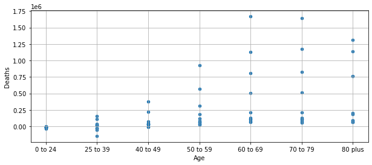

```python
age_deaths=covid_df[0:70][[AGE,DEATHS]]
age_deaths.sort_values(AGE).plot(x=AGE, y=DEATHS, grid=True, figsize=(10,4), kind='scatter')
```

The graph above depicts how death rate is lower in lower age groups and vice versa. We can determine how strong this correlation is using spearmanr function from scipy

```python
from scipy.stats import spearmanr
(corr, pval)=spearmanr(age_deaths[AGE], age_deaths[DEATHS])
(corr, pval)
```

```
(0.7257680021339493, 1.1784159753766996e-12)
```

Correlation is positive and strong at corr=0.726. A p-value of 1.17e-12 shows this correlation is statistically significant.

## Conclusion

We can conclude that death rate due to COVID-19 from the analysed data from WHO increases with age. Older people are prone to dying to the virus and should therefore take extra caution to prevent an infection.